# Homework Tidyverse

Salme Adeele Hollas

```r
if(!require("pacman")) install.packages("pacman")
pacman::p_load(tidyverse, gapminder, broom)
```

# Problem 1:

Copy paste and run the tribble given below.

```r
tribble( ~x,    ~y,    ~w,    ~z,
              210,   300,   220,   180,
              102,   100,   119,   187,
              176,   175,   188,   173,
              87,    95,   91,     94,
              202,   210,  234,    218,
              110,   122,  131,    128,
) -> dt
```

## 1_a:

```r
# Calculate the mean of each column using map()
map(dt, mean)
```

```
$x
[1] 147.8333

$y
[1] 167

$w
[1] 163.8333

$z
[1] 163.3333
```

I used the map() function to apply the mean() function to each column of dt. This gives the mean for each variable.

## 1_b:

```r
# Calculate the standard deviation of each column using map()
map(dt, sd)
```

```
$x
[1] 54.45151

$y
[1] 79.12016

$w
[1] 58.40348

$z
[1] 44.66617
```

I used the map() function to apply the sd() function to each column of dt. This gives the standard deviation for each variable.

## 1_c:

```r
# Calculate the square root of every value using map()
map(dt, sqrt)
```

```
$x
[1] 14.491377 10.099505 13.266499  9.327379 14.212670 10.488088

$y
[1] 17.320508 10.000000 13.228757  9.746794 14.491377 11.045361

$w
[1] 14.832397 10.908712 13.711309  9.539392 15.297059 11.445523

$z
[1] 13.41641 13.67479 13.15295  9.69536 14.76482 11.31371
```

I used the map() to apply the sqrt() function to every value in each column of dt.

## 1_d:

```r
summary(dt)
```

```
       x               y               w               z
 Min.   : 87.0   Min.   : 95.0   Min.   : 91.0   Min.   : 94.0
 1st Qu.:104.0   1st Qu.:105.5   1st Qu.:122.0   1st Qu.:139.2
 Median :143.0   Median :148.5   Median :159.5   Median :176.5
 Mean   :147.8   Mean   :167.0   Mean   :163.8   Mean   :163.3
 3rd Qu.:195.5   3rd Qu.:201.2   3rd Qu.:212.0   3rd Qu.:185.2
 Max.   :210.0   Max.   :300.0   Max.   :234.0   Max.   :218.0
```

I used the summary() function to calculate the minimum, 1st quartile, median, mean, 3rd quartile, and maximum for each column of dt.

# Problem 2:

Write a function that uses a for loop that, for each iteration, randomly draws 5 observations from an exponential distribution with “rate” parameter 1 (use `rexp()`) and calculates its “mean”. It should do this 10,000 times. Choose an appropriate plot to plot the distribution of “means”.

```r
# Function to generate 10,000 sample means
calculate_means <- function() {
  means <- vector("double", 10000)

  for (i in 1:10000) {
    sample <- rexp(5, rate = 1)
    means[i] <- mean(sample)
  }
  means
}
```

```r
means <- calculate_means()
head(means)
```

```
[1] 0.4262673 1.2942303 0.9296828 1.3702541 1.0171967 0.3097944
```

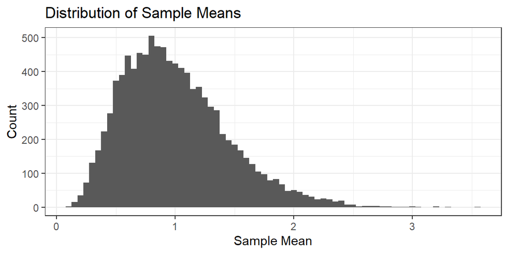

```r
# Create a data frame and plot the distribution of the sample means
means_df <- tibble(means = means)

ggplot(means_df, aes(x=means)) +
  geom_histogram(binwidth = 0.05) +
  labs(
    x= "Sample Mean",
    y = "Count",
    title = "Distribution of Sample Means"
  )
```

I stored the 10,000 sample means in a data frame and used a histogram to show their distribution.

## 2_a:

```r
# Generate 10,000 sample means using map()
means_map <- map_dbl(1:10000, ~ mean(rexp(5, rate = 1)))
head(means_map)
```

```
[1] 0.5612143 1.7083863 1.2800656 1.1741400 1.0885606 0.8190869
```

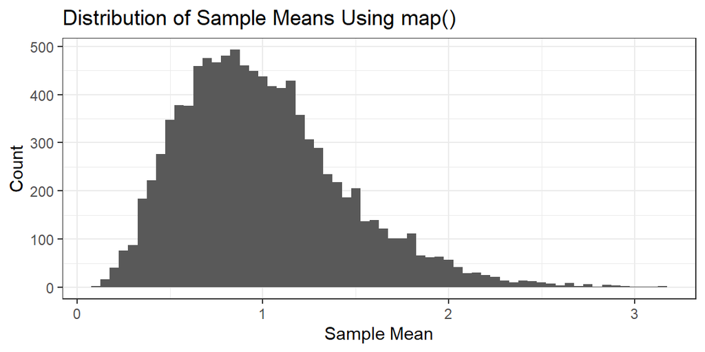

```r
# Plot the distribution of the sample means
means_map_df <- tibble(means = means_map)
ggplot(means_map_df, aes(x=means)) +
  geom_histogram(binwidth = 0.05) +
  labs(
    x = "Sample Mean",
    y = "Count",
    title = "Distribution of Sample Means Using map()"
  )
```

I used map_dbl() to generate 10,000 samples and calculate the mean of each sample. The histogram shows the distribution of these sample means.

## 2_b:

```r
# Generate 10,000 sample means using replicate()
means_replicate <- replicate(10000, mean(rexp(5, rate = 1)))
head(means_replicate)
```

```
[1] 1.2102548 1.0086143 0.8562023 0.8073765 1.2881303 1.0230874
```

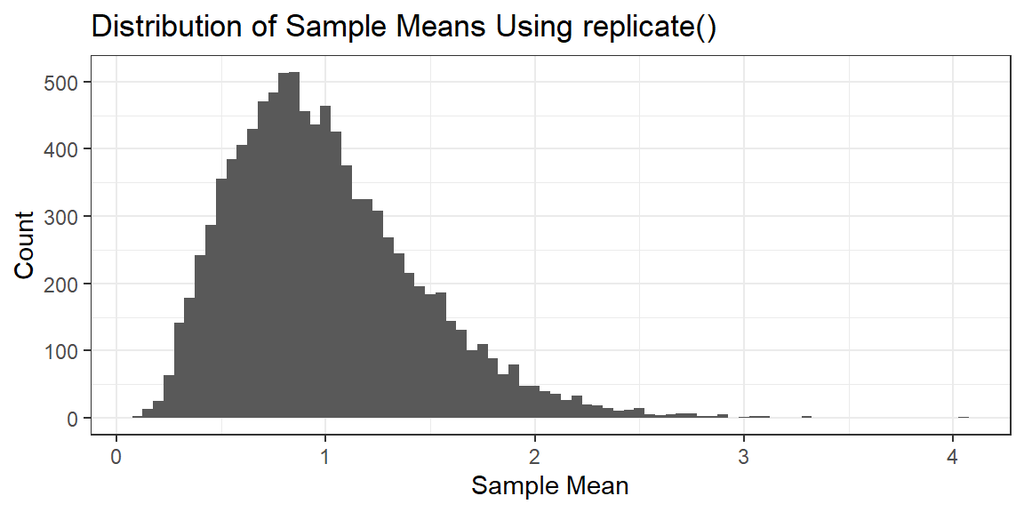

```r
means_replicate_df <- tibble(means = means_replicate)
ggplot(means_replicate_df, aes(x = means)) +
  geom_histogram(binwidth = 0.05) +
  labs(
    x = "Sample Mean",
    y = "Count",
    title = "Distribution of Sample Means Using replicate()"
  )
```

I used replicate() to repeat the sampling and mean calculation 10,000 times. The histogram shows the distribution of these sample means.

## 2_c:

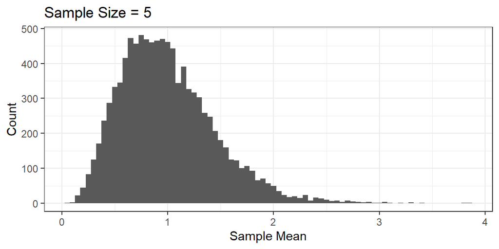

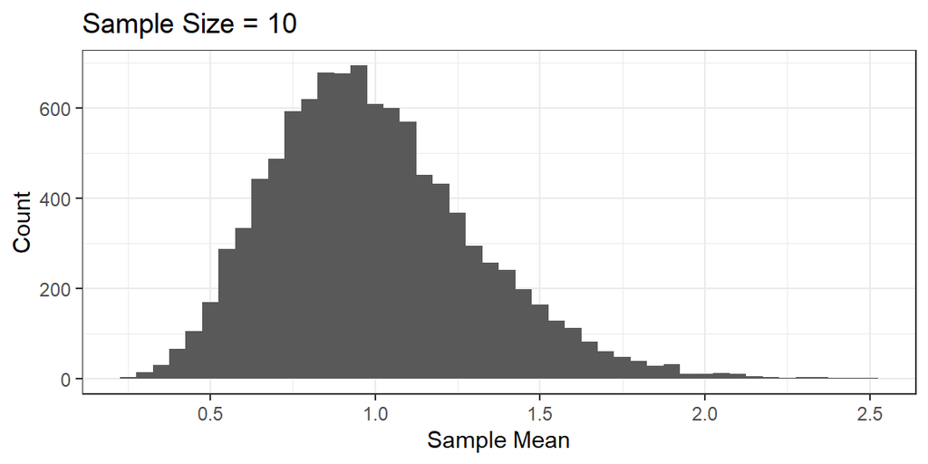

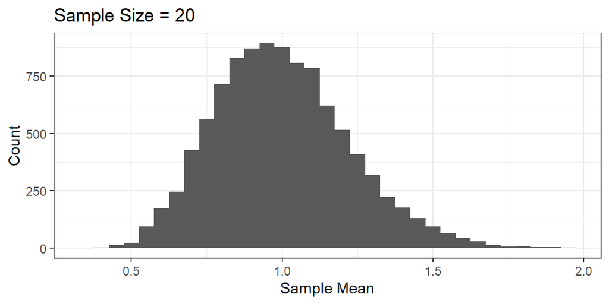

```r
# Generate sample means for sample sizes 5, 10, and 20
sample_sizes <- c(5, 10, 20)

for (n in sample_sizes) {
  means <- vector("double", 10000)
  for (i in 1:10000) {
    sample <- rexp(n, rate =1)
    means[i] <- mean(sample)
  }

  means_df <- tibble(means = means)

  print(
    ggplot(means_df, aes(x=means)) +
      geom_histogram(binwidth = 0.05) +
      labs(
        x="Sample Mean",
        y= "Count",
        title = paste("Sample Size =", n)
      )
  )
}
```

I used a for loop to generate 10,000 sample means for sample sizes of 5, 10, and 20. The histograms show that the distribution becomes narrower as the sample size increases.

# Problem 3:

```r
# Calculate the standard deviation of each variable in mtcars
output <- vector("double", ncol(mtcars))

for (i in seq_along(mtcars)) {
  output[[i]] <- sd(mtcars[[i]])
}

names(output) <- names(mtcars)
output
```

```
        mpg         cyl        disp          hp        drat          wt
  6.0269481   1.7859216 123.9386938  68.5628685   0.5346787   0.9784574
       qsec          vs          am        gear        carb
  1.7869432   0.5040161   0.4989909   0.7378041   1.6152000
```

I used the special for loop method to calculate the standard deviation of each variable in mtcars. The loop goes through each column and applies the sd() function.

# Problem 4:

```r
# Generate dates every 2 months from 2015 to 2025
dates <- tibble(
  date = seq(
    as.Date("2015-01-01"),
    as.Date("2025-12-31"),
    by = "2 months"
  )
) %>%
  mutate(
    year = year(date),
    quarter = quarter(date),
    iso_week = isoweek(date)
  )

dates
```

```
# A tibble: 66 × 4
   date        year quarter iso_week
   <date>     <dbl>   <int>    <dbl>
 1 2015-01-01  2015       1        1
 2 2015-03-01  2015       1        9
 3 2015-05-01  2015       2       18
 4 2015-07-01  2015       3       27
 5 2015-09-01  2015       3       36
 6 2015-11-01  2015       4       44
 7 2016-01-01  2016       1       53
 8 2016-03-01  2016       1        9
 9 2016-05-01  2016       2       17
10 2016-07-01  2016       3       26
# ℹ 56 more rows
```

I created a sequence of dates every two months and used lubridate functions to extract the year, quarter, and ISO week number for each date.

# Problem 5

```r
sample_dates <- c("2018-03-15", "2020-07-20", "2023-01-10", "2025-09-05")

# Convert the date strings to Date format
dates <- ymd(sample_dates)

# Calculate the difference between consecutive dates
date_differences <- tibble(
  from = dates[-length(dates)],
  to = dates[-1],
  months = time_length(interval(from, to), "months"),
  weeks = time_length(interval(from, to), "weeks")
)

date_differences
```

```
# A tibble: 3 × 4
  from       to         months weeks
  <date>     <date>      <dbl> <dbl>
1 2018-03-15 2020-07-20   28.2  123.
2 2020-07-20 2023-01-10   29.7  129.
3 2023-01-10 2025-09-05   31.8  138.
```

I converted the date strings to Date format and calculated the difference in months and weeks between each consecutive pair of dates.

# Problem 6

```r
date_strings <- list("2023-06-10", "2022/12/25", "15-Aug-2021", "InvalidDate")

# Safely convert different date formats to Date
safe_date <- possibly(
  function(x) {
    as.Date(parse_date_time(x, orders = c("ymd", "Y/m/d", "d-b-Y")))
  },
  otherwise = as.Date(NA)
)

# Convert the date strings
months <- map_chr(
  dates,
  ~ as.character(month(.x, label = TRUE, abbr = FALSE))
)

# Extract the month name
results <- tibble(
  date_string = unlist(date_strings),
  date = as.Date(unlist(dates)),
  month = unlist(months)
)


results
```

```
# A tibble: 4 × 3
  date_string date       month
  <chr>       <date>     <chr>
1 2023-06-10  2018-03-15 March
2 2022/12/25  2020-07-20 July
3 15-Aug-2021 2023-01-10 January
4 InvalidDate 2025-09-05 September
```